# Regression and model validation

The theme for the week 2 was regression analysis. Week 2 exercises consist of 1) data wrangling exercises and 2) data analysis exercises. You can find results of my second week below.

```r
# read the data into memory
std14 <- read.table("http://s3.amazonaws.com/assets.datacamp.com/production/course_2218/datasets/learning2014.txt", sep=",", header=TRUE)
```

The dataset consist from the 7 different variables (gender (factor), age (int), attitude (num), deep (num), stra(num), surf(num), and point(int)) and 166 observations. I excluded from the data those observations where the exam points were 0. You can find variables names and short descriptions and some basic charasteristics about the data below:

```r
#Explore structure and dimensions of the dataset
str(std14)
```

```
## 'data.frame':    166 obs. of  7 variables:
##  $ gender  : Factor w/ 2 levels "F","M": 1 2 1 2 2 1 2 1 2 1 ...
##  $ age     : int  53 55 49 53 49 38 50 37 37 42 ...
##  $ attitude: num  3.7 3.1 2.5 3.5 3.7 3.8 3.5 2.9 3.8 2.1 ...
##  $ deep    : num  3.58 2.92 3.5 3.5 3.67 ...
##  $ stra    : num  3.38 2.75 3.62 3.12 3.62 ...
##  $ surf    : num  2.58 3.17 2.25 2.25 2.83 ...
##  $ points  : int  25 12 24 10 22 21 21 31 24 26 ...
```

```r
dim(std14)
```

```
## [1] 166   7
```

```r
summary(std14)
```

```
##  gender       age           attitude          deep            stra
##  F:110   Min.   :17.00   Min.   :1.400   Min.   :1.583   Min.   :1.250
##  M: 56   1st Qu.:21.00   1st Qu.:2.600   1st Qu.:3.333   1st Qu.:2.625
##          Median :22.00   Median :3.200   Median :3.667   Median :3.188
##          Mean   :25.51   Mean   :3.143   Mean   :3.680   Mean   :3.121
##          3rd Qu.:27.00   3rd Qu.:3.700   3rd Qu.:4.083   3rd Qu.:3.625
##          Max.   :55.00   Max.   :5.000   Max.   :4.917   Max.   :5.000
##       surf           points
##  Min.   :1.583   Min.   : 7.00
##  1st Qu.:2.417   1st Qu.:19.00
##  Median :2.833   Median :23.00
##  Mean   :2.787   Mean   :22.72
##  3rd Qu.:3.167   3rd Qu.:27.75
##  Max.   :4.333   Max.   :33.00
```

According the graphical overview, age and gender variables are skewed but all the others variables are fairly normally distributed.

```r
# Access the tidyverse libraries tidyr, dplyr, ggplot2
library(tidyr); library(dplyr); library(ggplot2); library(corrplot)
glimpse(std14)
```

```
## Observations: 166
## Variables: 7
## $ gender   <fct> F, M, F, M, M, F, M, F, M, F, M, F, F, F, M, F, F, F,...
## $ age      <int> 53, 55, 49, 53, 49, 38, 50, 37, 37, 42, 37, 34, 34, 3...
## $ attitude <dbl> 3.7, 3.1, 2.5, 3.5, 3.7, 3.8, 3.5, 2.9, 3.8, 2.1, 3.9...
## $ deep     <dbl> 3.583333, 2.916667, 3.500000, 3.500000, 3.666667, 4.7...
## $ stra     <dbl> 3.375, 2.750, 3.625, 3.125, 3.625, 3.625, 2.250, 4.00...
## $ surf     <dbl> 2.583333, 3.166667, 2.250000, 2.250000, 2.833333, 2.4...
## $ points   <int> 25, 12, 24, 10, 22, 21, 21, 31, 24, 26, 31, 31, 23, 2...
```

```r
gather(std14) %>% glimpse
```

```
## Observations: 1,162
## Variables: 2
## $ key   <chr> "gender", "gender", "gender", "gender", "gender", "gende...
## $ value <chr> "F", "M", "F", "M", "M", "F", "M", "F", "M", "F", "M", "...
```

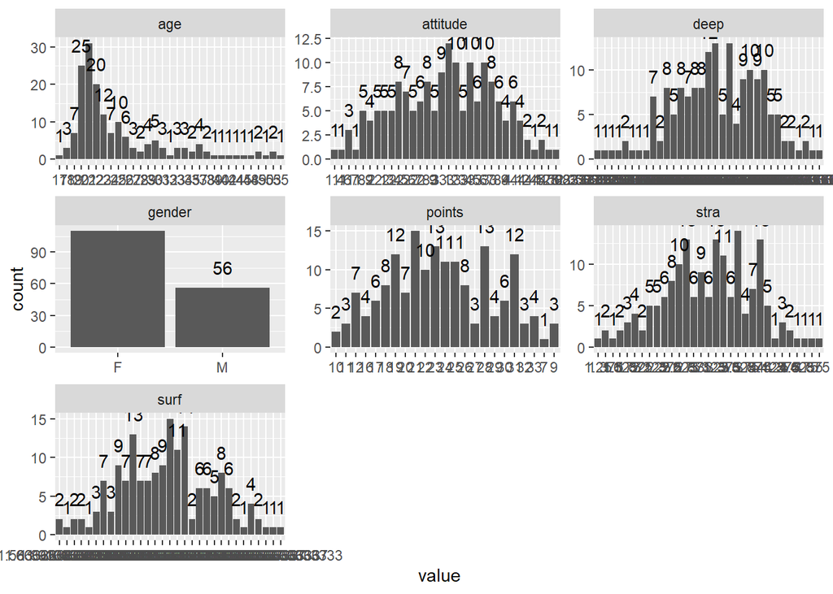

```r
# draw a bar plot of each variable and add frequency count labels above the bars
gather(std14) %>% ggplot(aes(value)) + facet_wrap("key", scales = "free") + geom_bar()+ geom_text(stat='count', aes(label=..count..), vjust=-1)
```

My aim was was find out the relationship between the exam points and attitude, age, and gender. Practically that mean how attitude, age, and gender associated with the achieved exam points in this population. First of all I made a correlation matrix (see below). Correlation is described as the analysis which lets us know the association or the absence of the relationship between two variables ‘x’ and ‘y’.

A correlation matrix is a table showing correlation coefficients between variables. Each cell in the table shows the correlation between two variables. A positive correlation mean a direct association between the two variables and a negative correlation a inverse association between two variables. If we focus on my main aim, we can found a positive correlation between points, gender (R=0.093) and attitude (R=0.436) and a negative correlation between points and age (R=0.093).

```r
# convert gender as integer
std14$gender <- as.integer(std14$gender)

# calculate the correlation matrix and round it
cor.matrix <- cor(std14)
head(round(cor.matrix,2))
```

```
##          gender   age attitude  deep  stra  surf points
## gender     1.00  0.12     0.29  0.06 -0.15 -0.11   0.09
## age        0.12  1.00     0.02  0.03  0.10 -0.14  -0.09
## attitude   0.29  0.02     1.00  0.11  0.06 -0.18   0.44
## deep       0.06  0.03     0.11  1.00  0.10 -0.32  -0.01
## stra      -0.15  0.10     0.06  0.10  1.00 -0.16   0.15
## surf      -0.11 -0.14    -0.18 -0.32 -0.16  1.00  -0.14
```

```r
cor.matrix
```

```
##               gender         age    attitude        deep        stra
## gender    1.00000000  0.11901733  0.29423035  0.05809597 -0.14552789
## age       0.11901733  1.00000000  0.02220071  0.02507804  0.10244409
## attitude  0.29423035  0.02220071  1.00000000  0.11024302  0.06174177
## deep      0.05809597  0.02507804  0.11024302  1.00000000  0.09650255
## stra     -0.14552789  0.10244409  0.06174177  0.09650255  1.00000000
## surf     -0.11269987 -0.14140516 -0.17554218 -0.32380198 -0.16097287
## points    0.09290782 -0.09319032  0.43652453 -0.01014849  0.14612247
##                surf      points
## gender   -0.1126999  0.09290782
## age      -0.1414052 -0.09319032
## attitude -0.1755422  0.43652453
## deep     -0.3238020 -0.01014849
## stra     -0.1609729  0.14612247
## surf      1.0000000 -0.14435642
## points   -0.1443564  1.00000000
```

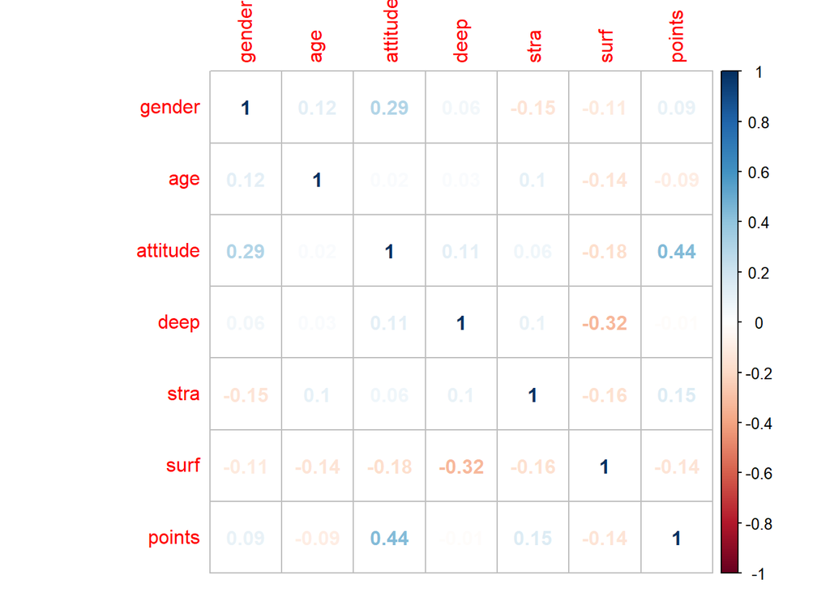

```r
# visualize the correlation matrix
corrplot(cor.matrix, method = "number")
```

After correlation analysis I made and a regression analysis. Regression analysis, predicts the value of the dependent variable based on the known value of the independent variable, assuming that average mathematical relationship between two or more variables.

```r
# create a regression model with multiple explanatory variables
my_model1 <- lm(points ~ attitude + age + gender, data = std14)

# print out a summary of the model
summary(my_model1)
```

```
##
## Call:
## lm(formula = points ~ attitude + age + gender, data = std14)
##
## Residuals:
##      Min       1Q   Median       3Q      Max
## -17.4590  -3.3221   0.2186   4.0247  10.4632
##
## Coefficients:
##             Estimate Std. Error t value Pr(>|t|)
## (Intercept) 13.75963    2.31478   5.944 1.65e-08 ***
## attitude     3.60657    0.59322   6.080 8.34e-09 ***
## age         -0.07586    0.05367  -1.414    0.159
## gender      -0.33054    0.91934  -0.360    0.720
## ---
## Signif. codes:  0 '***' 0.001 '**' 0.01 '*' 0.05 '.' 0.1 ' ' 1
##
## Residual standard error: 5.315 on 162 degrees of freedom
## Multiple R-squared:  0.2018, Adjusted R-squared:  0.187
## F-statistic: 13.65 on 3 and 162 DF,  p-value: 5.536e-08
```

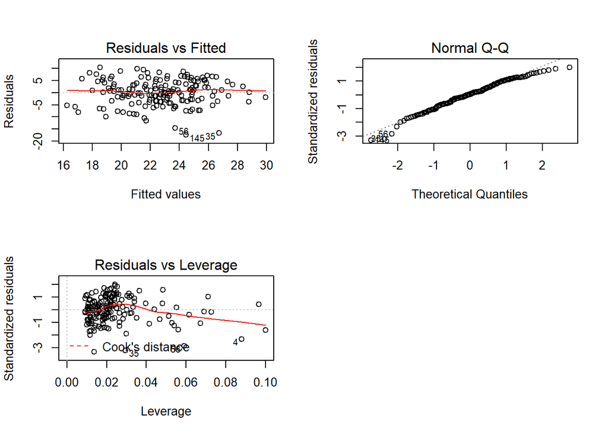

```r
# draw diagnostic plots using the plot() function. Choose the plots Residuals vs Fitted values = 1, Normal QQ-plot = 2 and Residuals vs Leverage = 5
par(mfrow = c(2,2))
plot(my_model1, which = c(1,2,5))
```

Let’s explain the analysis output step by step.

## Formula Call

As you can see, the first item shown in the output is the formula R used to fit the data. Note the simplicity in the syntax: the formula just needs the predictors (attitude, age, gender) and the target/response variable (points), together with the data being used (std14).

## Residuals

The next item in the model output talks about the residuals. Residuals are essentially the difference between the actual observed response values and the response values that the model predicted. The Residuals section of the model output breaks it down into 5 summary points. When assessing how well the model fit the data, you should look for a symmetrical distribution across these points on the mean value zero (0).

## Coefficients

The next section in the model output talks about the coefficients of the model.

## Coefficient - Standard Error

The coefficient Standard Error measures the average amount that the coefficient estimates vary from the actual average value of our response variable.

## Coefficient - t value

The coefficient t-value is a measure of how many standard deviations our coefficient estimate is far away from 0. We want it to be far away from zero as this would indicate we could reject the null hypothesis - that is, we could declare a relationship between attitude and exam points.

## Multiple R-squared, Adjusted R-squared

The R-squared (R2) statistic provides a measure of how well the model is fitting the actual data. It takes the form of a proportion of variance. R2 is a measure of the linear relationship between our predictor variable (attitude, age and gender) and our response / target variable (exam points). It always lies between 0 and 1 (i.e.: a number near 0 represents a regression that does not explain the variance in the response variable well and a number close to 1 does explain the observed variance in the response variable). In our example, the R2 we get is 0.2018. Or roughly 20% of the variance found in the response variable (exam points) can be explained by the predictor variable (attitude, age and gender).

## F-Statistic

F-statistic is a good indicator of whether there is a relationship between our predictor and the response variables. The further the F-statistic is from 1 the better it is. However, how much larger the F-statistic needs to be depends on both the number of data points and the number of predictors. Generally, when the number of data points is large, an F-statistic that is only a little bit larger than 1 is already sufficient to reject the null hypothesis (H0 : There is no relationship between attitude+age+gender, and exam points). The reverse is true as if the number of data points is small, a large F-statistic is required to be able to ascertain that there may be a relationship between predictor and response variables. In our example the F-statistic is 13,65 which is relatively larger than 1 given the size of our data.

Last I checked graphically the validity of the model assumptions. For that I produced the following diagnostic plots: Residuals vs Fitted values, Normal QQ-plot and Residuals vs Leverage. Let’s begin by looking at the Residual-Fitted plot coming from a linear model that is fit to data that perfectly satisfies all the of the standard assumptions of linear regression. The scatterplot shows good setup for a linear regression: The data appear to be well modeled by a linear relationship between y and x, and the points appear to be randomly spread out about the line, with no discerninle non-linear trends or changes in variability.

The Normal QQ plot helps us to assess whether the residuals are roughly normally distributed. In this case residual match pretty good to the diagonal line. It means that residuals are pretty normally distributed (that is on another assumption).

Outliers and the Residuals vs Leverage plot. There’s no single accepted definition for what consitutes an outlier. This case is the typical look when there is no influential case, or cases. Because we can not see Cook’s distance lines (a red dashed line) because all cases are well inside of the Cook’s distance lines.